# R Notebook

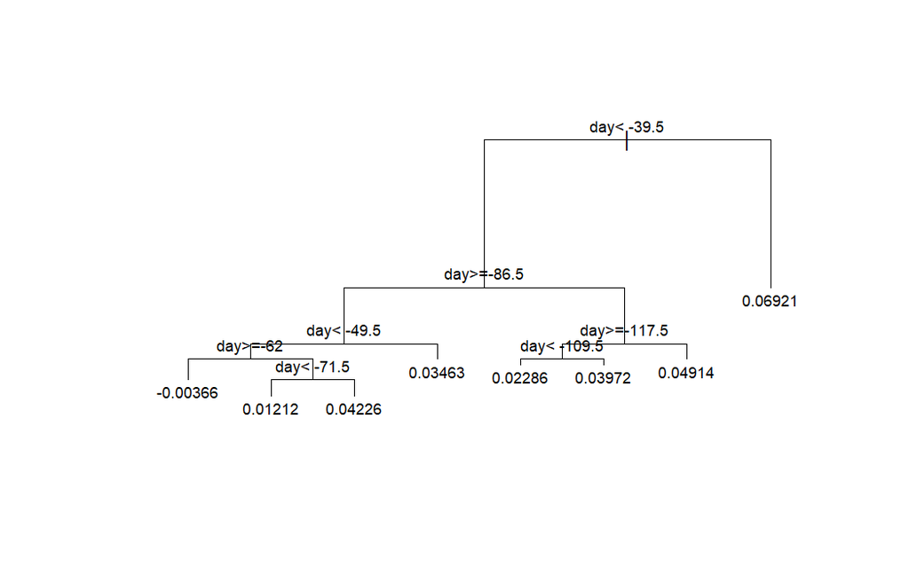

```r
# Load tidyverse
library(tidyverse)

# load package for decision tree
library(rpart)

# load the dslabs package
library(dslabs)

# fit a classification tree using the polls_2008 dataset,
# which contains only one predictor (day)
# and the outcome (margin)
fit <- rpart(margin ~ ., data = polls_2008)

# display the decision tree
plot(fit, margin = 0.1)
text(fit, cex = 0.75)
```

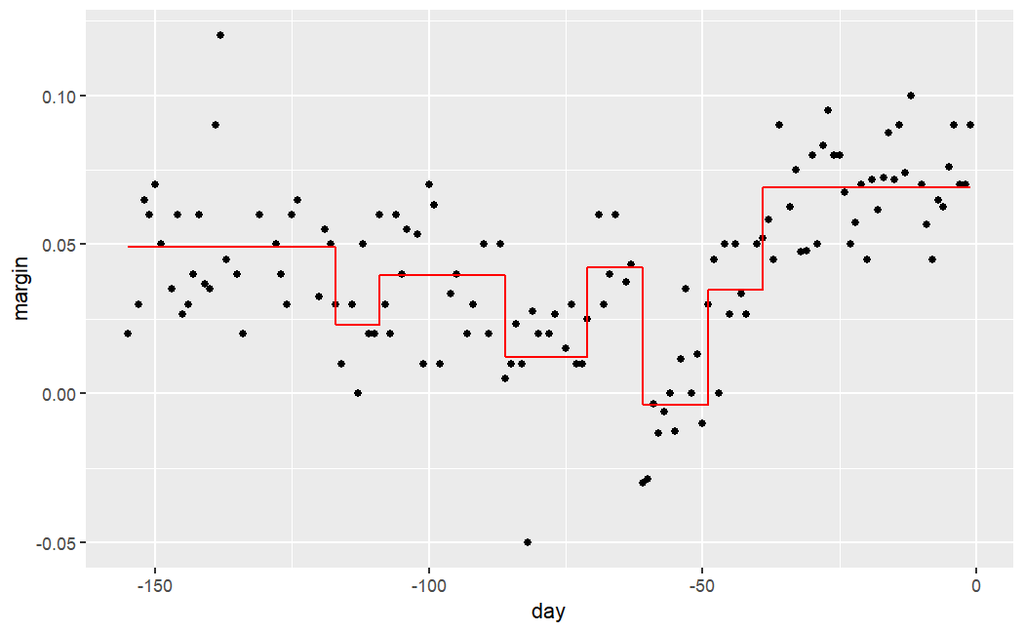

```r
# examine the fit from the classification tree model
polls_2008 %>%
  mutate(y_hat = predict(fit)) %>%
  ggplot() +
  geom_point(aes(day, margin)) +
  geom_step(aes(day, y_hat), col="red")
```

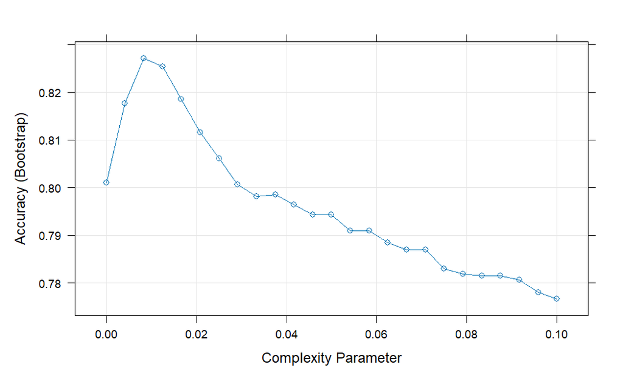

```r
# fit a classification tree on the mnist data using cross validation
train_rpart <- train(y ~ .,
              method = "rpart",
              tuneGrid = data.frame(cp = seq(0.0, 0.1, len = 25)),
              data = mnist_27$train)
# and plot it
plot(train_rpart)
```

```r
# compute accuracy
confusionMatrix(predict(train_rpart, mnist_27$test), mnist_27$test$y)$overall["Accuracy"]
```

```
Accuracy
    0.82
```

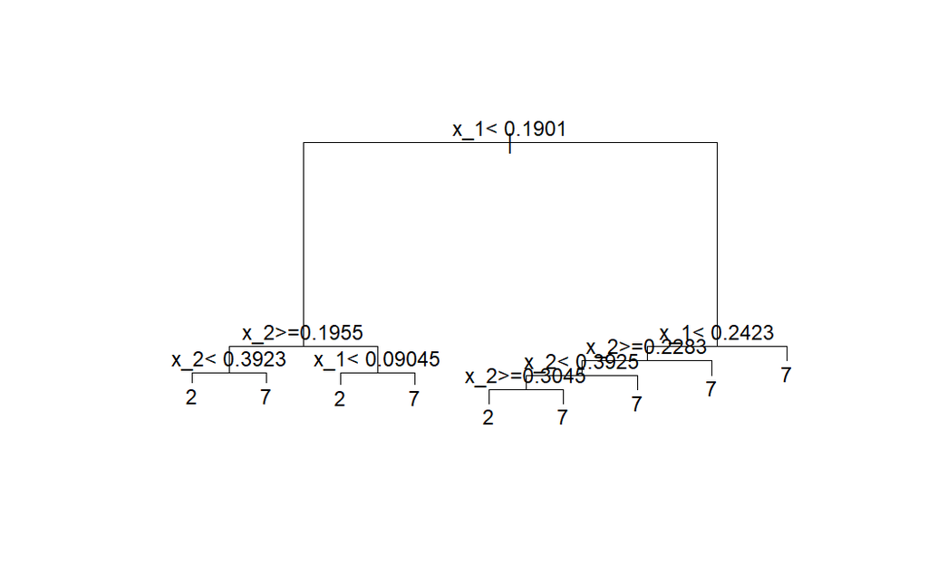

```r
# view the final decision tree
plot(train_rpart$finalModel, margin = 0.1) # plot tree structure
text(train_rpart$finalModel) # add text labels
```

```r
# load library for random forest
library(randomForest)
train_rf <- randomForest(y ~ ., data=mnist_27$train)
confusionMatrix(predict(train_rf, mnist_27$test), mnist_27$test$y)$overall["Accuracy"]
```

```
Accuracy
   0.785
```

```r
# use cross validation to choose parameter
train_rf_2 <- train(y ~ .,
      method = "Rborist",
      tuneGrid = data.frame(predFixed = 2, minNode = c(3, 50)),
      data = mnist_27$train)
```

```
1 package is needed and is not installed. (Rborist). Would you like to try to install it now?
1: yes
2: no
```

```r
1
```

```
G3;Installing package into ‘C:/Users/Public/R/R4_libs_x86_64’
gtrying URL 'https://cran.wu.ac.at/bin/windows/contrib/4.5/Rborist_0.3-11.zip'
```

```r
confusionMatrix(predict(train_rf_2, mnist_27$test), mnist_27$test$y)$overall["Accuracy"]
```

```
Accuracy
   0.805
```

```r
library(rpart)
n <- 1000
sigma <- 0.25
set.seed(1)
x <- rnorm(n, 0, 1)
y <- 0.75 * x + rnorm(n, 0, sigma)
dat <- data.frame(x = x, y = y)
fit <- rpart(y ~ ., data = dat)
dat %>%
    mutate(y_hat = predict(fit)) %>%
    ggplot() +
    geom_point(aes(x, y)) +
  geom_step(aes(x, y_hat), col=2)
```

[output not shown]

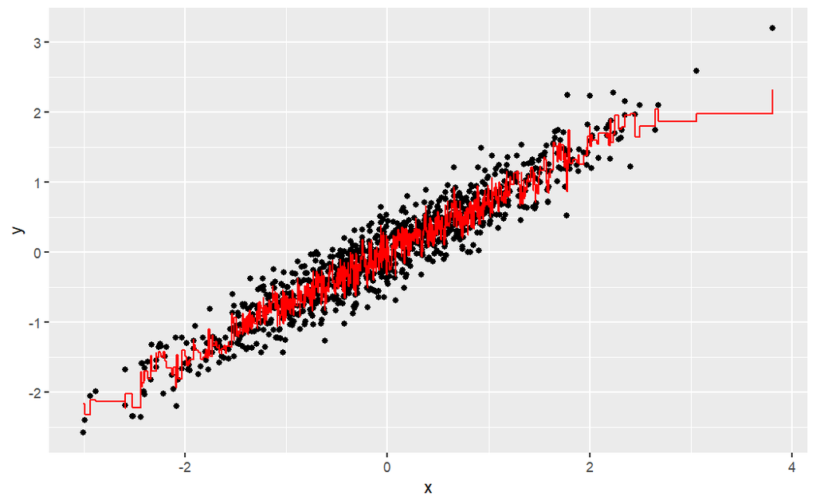

```r
library(randomForest)
fit <- randomForest(y ~ x, data = dat)
dat %>%
    mutate(y_hat = predict(fit)) %>%
    ggplot() +
    geom_point(aes(x, y)) +
    geom_step(aes(x, y_hat), col = "red")
```

Below is a set of commands for the Caret packages test sequence. Go back over this to explain what is happening

```r
library (caret)
library (rpart)
data (tissue_gene_expression)
# cp <- seq(0, 0.1, 0.01)
set.seed(1991)

fit <- with(tissue_gene_expression,
                train(x, y, method = "rpart", control = rpart.control(minsplit = 0),
                      tuneGrid = data.frame(cp = seq(0, 0.1, 0.01))))

#fit2 <- tissue_gene_expression |> train(x, y, method = "rpart",
#                      tuneGrid = data.frame(cp = seq(0, 0.1, 0.01)))

confusionMatrix(fit)$overall["Accuracy"]
```

[output not shown]

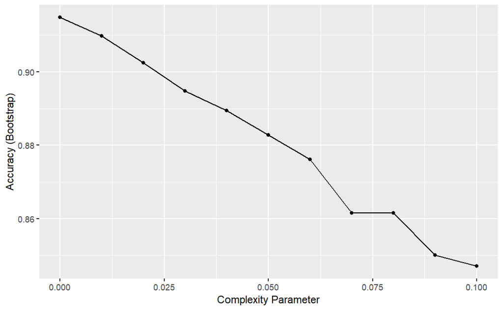

```r
ggplot(fit)
```

```r
#fit == fit2
```

Q4: We can see that with just seven genes, we are able to predict the tissue type. Now let’s see if we can predict the tissue type with even fewer genes using a Random Forest. Use the train() function and the rf method to train a Random Forest model and save it to an object called fit. Try out values of mtry ranging from seq(50, 200, 25) (you can also explore other values on your own). What mtry value maximizes accuracy? To permit small nodesize to grow as we did with the classification trees, use the following argument: nodesize = 1.

Note: This exercise will take some time to run. If you want to test out your code first, try using smaller values with ntree. Set the seed to 1991 again. What value of mtry maximizes accuracy?

ggplot (fit) - what is happening here: it is clearly more behid it that the simple plot

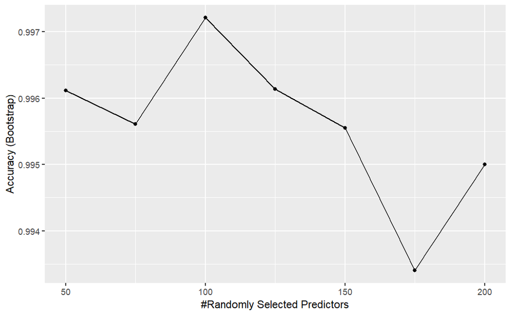

```r
set.seed(1991)
fit <- with(tissue_gene_expression,
                train(x, y, method = "rf", nodesize = 1,
                      tuneGrid = data.frame(mtry = seq(50, 200, 25))))
ggplot(fit)
```